# Homework #6

Jessica Karch

October 17, 2016

## 19.

**a.** Draw a scatter plot of these data. Which variable should be the explanatory variable (*X*), and wich should be the response variable (*Y*)?

```r
# Load libraries
library(readr)
library(dplyr)
```

```r
library(ggplot2)
# Load data
plants <- read_csv("data/chap17q19GrasslandNutrientsPlantSpecies.csv")
# Inspect data
plants
```

```
## # A tibble: 10 × 2
##    nutrients species
##        <int>   <int>
## 1          0      36
## 2          0      36
## 3          0      32
## 4          1      34
## 5          2      33
## 6          3      30
## 7          1      20
## 8          3      23
## 9          4      21
## 10         4      16
```

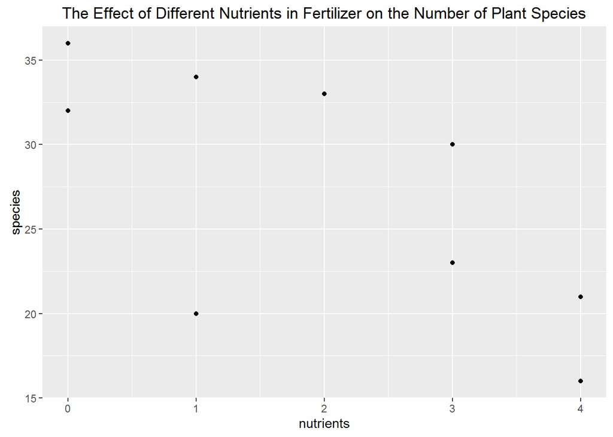

```r
# Draw a scatter plot
plants_plot <- ggplot(data = plants, mapping = aes(x = nutrients, y = species)) +
  geom_point() +
  labs(title = "The Effect of Different Nutrients in Fertilizer on the Number of Plant Species")
# Look at plot
plants_plot
```

The number of nutrients added is the explanatory variable *X* and the number of plant species is the response variable *Y*.

**b.** What is the rate of change in the number of plant species supported per nutrient type added? Provide a standard error for your estimate.

```r
# Fit a linear model
plants_lm <- lm(species ~ nutrients, data = plants)
# Look at the slope, standard error
summary(plants_lm)
```

```
##
## Call:
## lm(formula = species ~ nutrients, data = plants)
##
## Residuals:
##     Min      1Q  Median      3Q     Max
## -10.771  -1.856   1.068   2.894   5.907
##
## Coefficients:
##             Estimate Std. Error t value Pr(>|t|)
## (Intercept)   34.110      2.599   13.12 1.08e-06 ***
## nutrients     -3.339      1.098   -3.04   0.0161 *
## ---
## Signif. codes:  0 '***' 0.001 '**' 0.01 '*' 0.05 '.' 0.1 ' ' 1
##
## Residual standard error: 5.336 on 8 degrees of freedom
## Multiple R-squared:  0.536,  Adjusted R-squared:  0.478
## F-statistic: 9.241 on 1 and 8 DF,  p-value: 0.01607
```

The rate of change is -3.3 +/- 1.1 plant species supported per nutrient type added.

**c.** Add the least-squares regression line to your scatter plot. What fraction of the variation in the number of plant species is “explained” by the number of nutrients added?

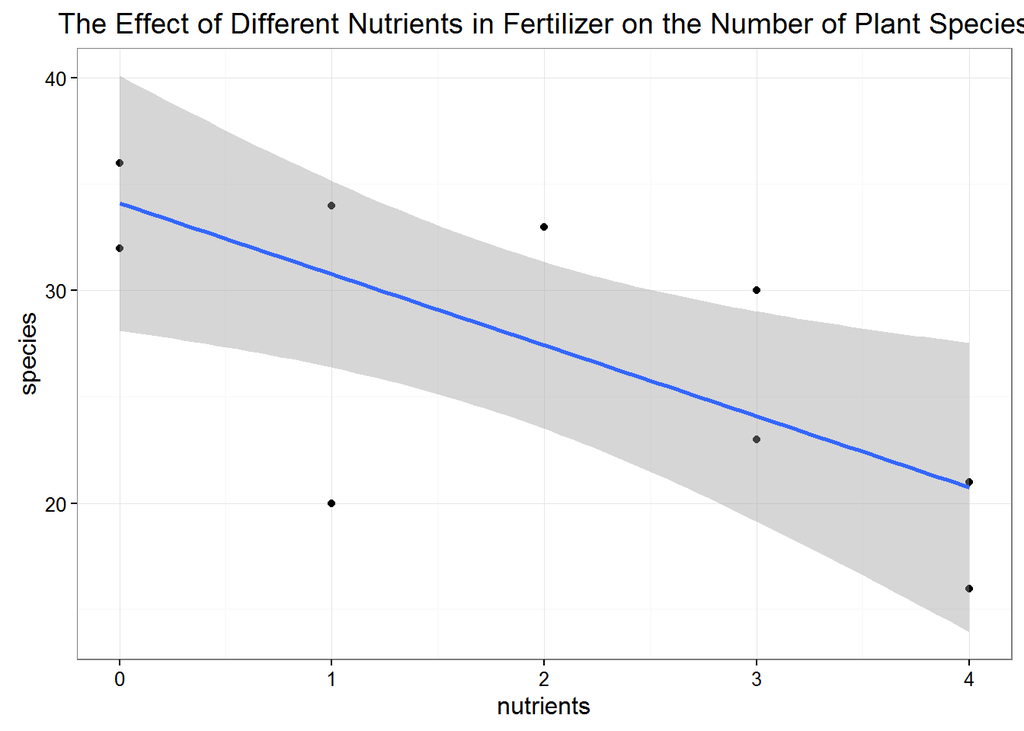

```r
# Make a regression line to the scatter plot
plants_plot +
  stat_smooth(method = "lm") +
  theme_bw()
```

**d.** Test the null hypothesis of no treatment effect on the number of plant species.

```r
# Do an f test
anova(plants_lm)
```

```
## Analysis of Variance Table
##
## Response: species
##           Df Sum Sq Mean Sq F value  Pr(>F)
## nutrients  1 263.11 263.112  9.2406 0.01607 *
## Residuals  8 227.79  28.474
## ---
## Signif. codes:  0 '***' 0.001 '**' 0.01 '*' 0.05 '.' 0.1 ' ' 1
```

```r
# Look at the R^2 values, p-values
summary(plants_lm)
```

```
##
## Call:
## lm(formula = species ~ nutrients, data = plants)
##
## Residuals:
##     Min      1Q  Median      3Q     Max
## -10.771  -1.856   1.068   2.894   5.907
##
## Coefficients:
##             Estimate Std. Error t value Pr(>|t|)
## (Intercept)   34.110      2.599   13.12 1.08e-06 ***
## nutrients     -3.339      1.098   -3.04   0.0161 *
## ---
## Signif. codes:  0 '***' 0.001 '**' 0.01 '*' 0.05 '.' 0.1 ' ' 1
##
## Residual standard error: 5.336 on 8 degrees of freedom
## Multiple R-squared:  0.536,  Adjusted R-squared:  0.478
## F-statistic: 9.241 on 1 and 8 DF,  p-value: 0.01607
```